# 市场观察

2017/08/31

## A、指数估值

### (a1)动态市盈率、市净率

核心指数成分股近18个月的动态市盈率及动态市净率中位数走势如下图所示：

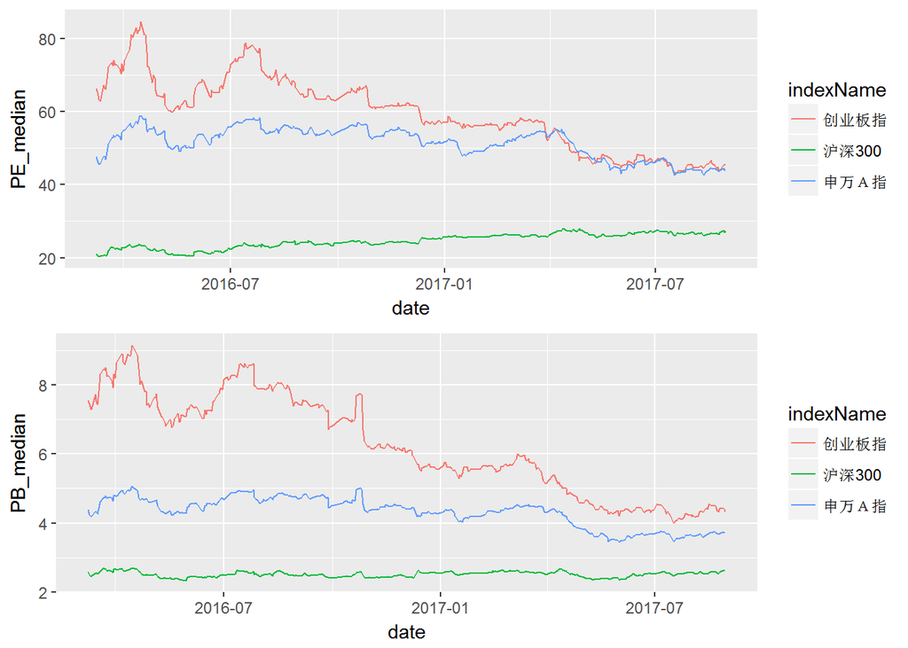

### (a2)动态市盈率、市净率百分位

核心指数近18个月的动态市盈率百分位及动态市净率百分位走势如下图所示：

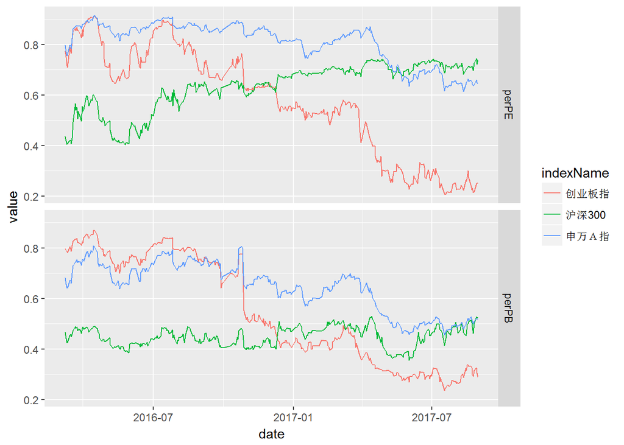

### (a3)指数估值概览

纳入观察的指数最新的估值情况如下表，根据市盈率和市净率分位数均值降序排列。

| 指数代码 | 指数简称 | 日期 | 动态市盈率 | 市盈率百分位 | 动态市净率 | 市净率百分位 |
| --- | --- | --- | --- | --- | --- | --- |
| EI000819 | 有色金属 | 2017-08-30 | 62.1 | 82% | 3.7 | 73% |
| EI000300 | 沪深300 | 2017-08-30 | 27.3 | 74% | 2.6 | 53% |
| EI000979 | 大宗商品 | 2017-08-30 | 35.5 | 65% | 2.7 | 60% |
| EI801003 | 申万Ａ指 | 2017-08-30 | 43.9 | 65% | 3.7 | 52% |
| EI399330 | 深证100 | 2017-08-30 | 30.3 | 60% | 3.5 | 45% |
| EI000934 | 中证金融 | 2017-08-30 | 21.3 | 76% | 1.9 | 27% |
| EI399959 | 军工指数 | 2017-08-30 | 76.9 | 50% | 3.9 | 49% |
| EI399005 | 中小板指P | 2017-08-30 | 38.0 | 52% | 4.5 | 41% |
| EI000922 | 中证红利 | 2017-08-30 | 17.6 | 59% | 1.8 | 33% |
| EI000905 | 中证500 | 2017-08-30 | 35.0 | 44% | 2.9 | 35% |
| EI000998 | 中证TMT | 2017-08-30 | 43.4 | 49% | 3.6 | 29% |
| EI000016 | 上证50 | 2017-08-30 | 17.8 | 61% | 1.6 | 17% |
| EI000932 | 中证消费 | 2017-08-30 | 30.7 | 40% | 4.0 | 35% |
| EI399006 | 创业板指 | 2017-08-30 | 45.4 | 25% | 4.3 | 29% |
| EI000827 | 中证环保 | 2017-08-30 | 32.7 | 13% | 3.0 | 27% |
| EI000933 | 中证医药 | 2017-08-30 | 31.2 | 13% | 3.5 | 1% |

### (a4)另类估值

我国10年期国债收益率、金银比价、金油比价，2000年以来的历史百分位如下图所示：

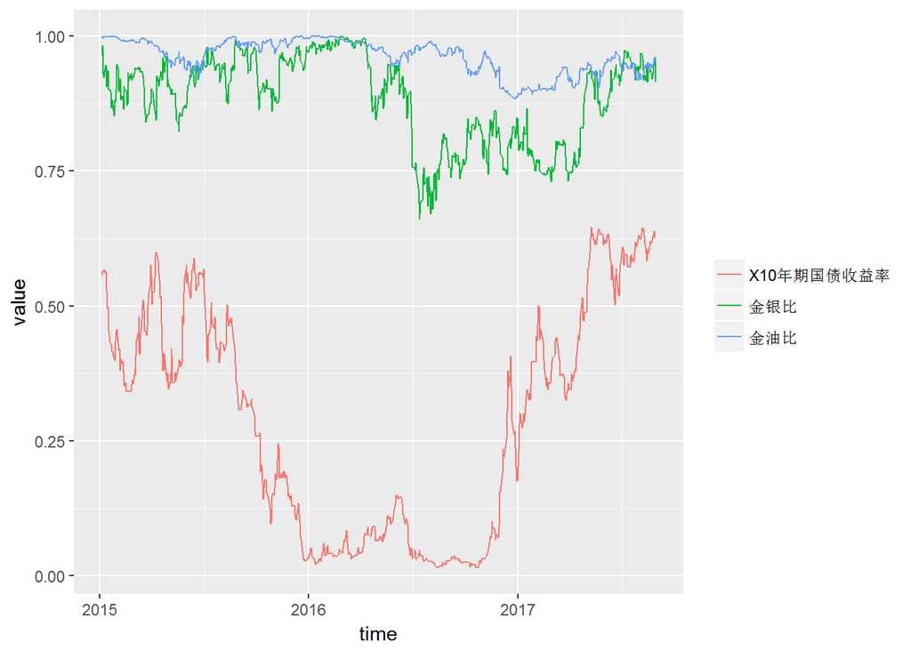

## B、基差及市场情绪

### (b1)基差走势

三大股指期货合约基差走势如下图，其中当月合约和次月合约年化基差百分比波动较大，仅展示合约基差百分比，当季合约和次季合约展示基差年化百分比：

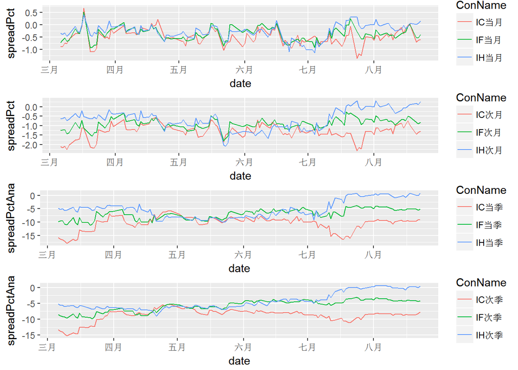

### (b2)基差概况

三大股指期货连续合约基差概况如下表，近月合约临近到期日，年化基差百分比数据波动较大：

| 日期 | 合约代码 | 合约收盘价 | 指数收盘价 | 基差 | 基差百分比 | 年化基差百分比 |
| --- | --- | --- | --- | --- | --- | --- |
| 2017-08-23 | IC1709 | 6285.2 | 6322.8 | -37.6 | -0.6% | -9.9% |
| 2017-08-23 | IC1710 | 6241.0 | 6322.8 | -81.8 | -1.3% | -8.4% |
| 2017-08-23 | IC1712 | 6149.2 | 6322.8 | -173.6 | -2.7% | -9.1% |
| 2017-08-23 | IC1803 | 6052.4 | 6322.8 | -270.4 | -4.3% | -7.7% |
| 2017-08-23 | IF1709 | 3741.6 | 3756.1 | -14.5 | -0.4% | -6.3% |
| 2017-08-23 | IF1710 | 3725.4 | 3756.1 | -30.7 | -0.8% | -5.3% |
| 2017-08-23 | IF1712 | 3698.0 | 3756.1 | -58.1 | -1.5% | -5.0% |
| 2017-08-23 | IF1803 | 3670.0 | 3756.1 | -86.1 | -2.3% | -4.1% |
| 2017-08-23 | IH1709 | 2664.2 | 2659.8 | 4.4 | 0.2% | 2.7% |
| 2017-08-23 | IH1710 | 2667.2 | 2659.8 | 7.4 | 0.3% | 1.8% |
| 2017-08-23 | IH1712 | 2667.2 | 2659.8 | 7.4 | 0.3% | 0.9% |
| 2017-08-23 | IH1803 | 2666.8 | 2659.8 | 7.0 | 0.3% | 0.5% |

### (b3)市场情绪(provided by han.qian)

市场情绪记录近60天每天自然涨跌停(剔除一字板)、创60日新高新低、多头排列空头排列(均线组合5,30,60,120)的股票数。

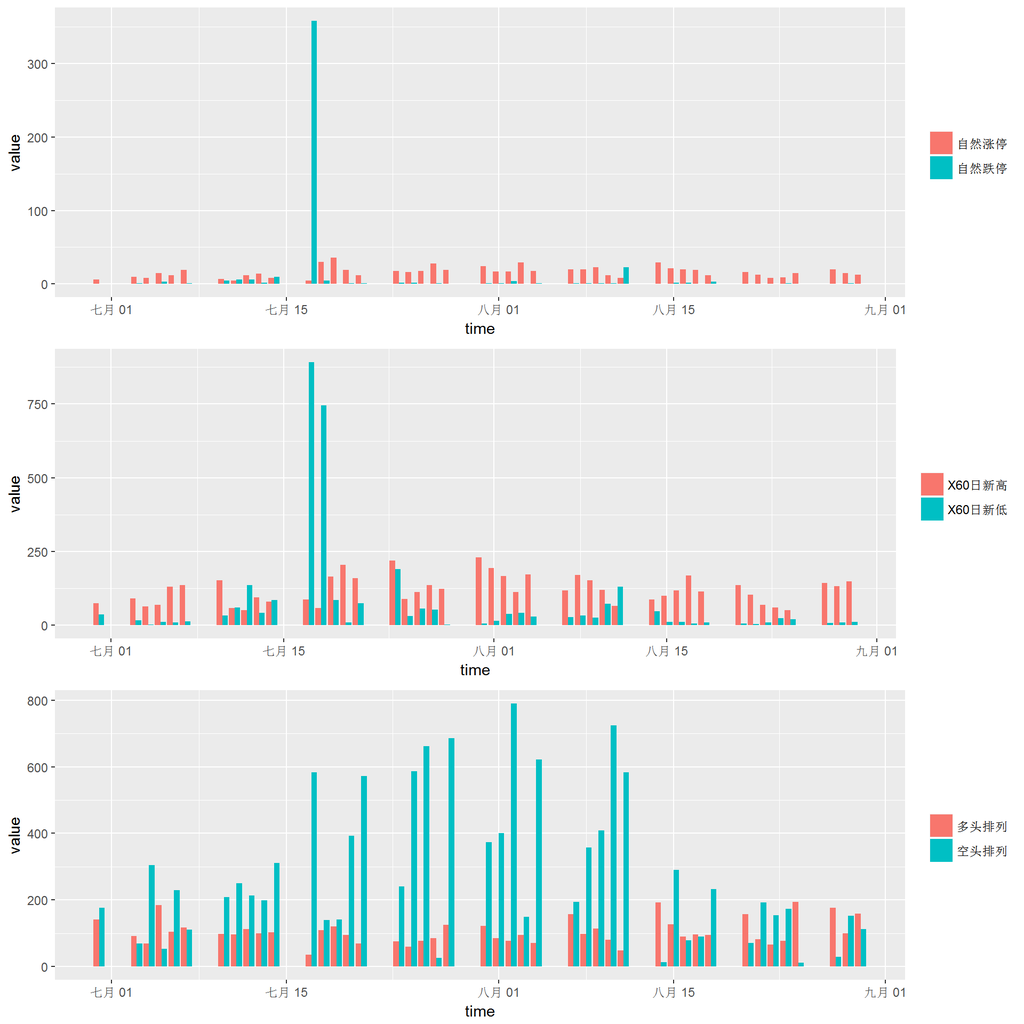

## C、套利和事件

### (c1)复牌股票套利

近两天复牌股票套利情况如下表：

[1] “No Arbitrage!”

### (c2)解禁

解禁分成两个部分，定增解禁和IPO解禁，涨跌幅记录是过去十个交易日的股票涨跌幅和对应行业指数涨跌幅。伴随着去年下半年IPO逐步正常化，今后IPO解禁给市场造成的抛压会持续存在，所以纳入观察。近期定增解禁的股票情况如下表。

| 股票代码 | 股票简称 | 解禁日 | 解禁数量 | 解禁百分比 | 区间涨跌幅 | 所属行业指数 | 行业指数涨跌幅 |
| --- | --- | --- | --- | --- | --- | --- | --- |
| EQ600658 | 电子城 | 2017-09-01 | 2.19 | 38% | 0.9% | 申万房地产 | 3.1% |
| EQ600844 | *ST丹科 | 2017-09-01 | 2.38 | 41% | -4.6% | 申万化工 | 1.7% |
| EQ300084 | 海默科技 | 2017-09-04 | 0.60 | 24% | 7.2% | 申万机械设备 | 1.8% |
| EQ300116 | 坚瑞沃能 | 2017-09-04 | 8.10 | 120% | -2.8% | 申万电子 | 1.6% |
| EQ002542 | 中化岩土 | 2017-09-04 | 3.24 | 52% | -3.4% | 申万建筑装饰 | 3.3% |
| EQ000876 | 新希望 | 2017-09-04 | 7.09 | 21% | -0.8% | 申万农林牧渔 | 2.8% |
| EQ002446 | 盛路通信 | 2017-09-05 | 1.11 | 34% | -5.5% | 申万通信 | 3.6% |
| EQ002602 | 世纪华通 | 2017-09-05 | 4.10 | 70% | 4.8% | 申万传媒 | 0.1% |
| EQ600221 | 海航控股 | 2017-09-06 | 46.24 | 39% | 0.6% | 申万交通运输 | 3.4% |
| EQ002747 | 埃斯顿 | 2017-09-08 | 0.98 | 55% | -5.1% | 申万机械设备 | 1.8% |
| EQ300108 | 吉药控股 | 2017-09-11 | 3.05 | 93% | 1.9% | 申万医药生物 | 0.5% |
| EQ600155 | 宝硕股份 | 2017-09-11 | 7.16 | 174% | 2.9% | 申万非银金融 | 7.7% |
| EQ600485 | 信威集团 | 2017-09-11 | 12.92 | 79% | 0.0% | 申万通信 | 3.6% |
| EQ002197 | 证通电子 | 2017-09-13 | 0.94 | 28% | 3.0% | 申万计算机 | 1.8% |

近期IPO解禁的股票情况如下表。

| 股票代码 | 股票简称 | 解禁日 | 解禁数量 | 解禁百分比 | 区间涨跌幅 | 所属行业指数 | 行业指数涨跌幅 | 上市日 |
| --- | --- | --- | --- | --- | --- | --- | --- | --- |
| EQ603658 | 安图生物 | 2017-09-01 | 0.95 | 225% | 2.3% | 申万医药生物 | 0.5% | 2016-09-01 |
| EQ002807 | 江阴银行 | 2017-09-04 | 5.09 | 243% | 2.0% | 申万银行 | 5.2% | 2016-09-02 |
| EQ603843 | 正平股份 | 2017-09-05 | 0.93 | 93% | -0.3% | 申万建筑装饰 | 3.3% | 2016-09-05 |
| EQ603806 | 福斯特 | 2017-09-05 | 3.12 | 346% | -2.6% | 申万电气设备 | 1.6% | 2014-09-05 |
| EQ300543 | 朗科智能 | 2017-09-08 | 0.09 | 30% | -5.8% | 申万电子 | 1.6% | 2016-09-08 |
| EQ300392 | 腾信股份 | 2017-09-11 | 2.18 | 133% | -2.3% | 申万传媒 | 0.1% | 2014-09-10 |
| EQ300108 | 吉药控股 | 2017-09-11 | 3.05 | 93% | 1.9% | 申万医药生物 | 0.5% | 2010-08-25 |
| EQ300395 | 菲利华 | 2017-09-11 | 0.72 | 34% | -2.2% | 申万有色金属 | 4.6% | 2014-09-10 |
| EQ601163 | 三角轮胎 | 2017-09-11 | 0.80 | 40% | 0.2% | 申万化工 | 1.7% | 2016-09-09 |
| EQ300396 | 迪瑞医疗 | 2017-09-11 | 1.07 | 229% | 0.5% | 申万医药生物 | 0.5% | 2014-09-10 |
| EQ300397 | 天和防务 | 2017-09-11 | 1.33 | 129% | -12.8% | 申万国防军工 | -2.0% | 2014-09-10 |
| EQ603188 | 亚邦股份 | 2017-09-11 | 1.97 | 52% | -5.0% | 申万化工 | 1.7% | 2014-09-09 |
| EQ603393 | 新天然气 | 2017-09-12 | 0.56 | 139% | 4.6% | 申万公用事业 | 1.5% | 2016-09-12 |
| EQ002729 | 好利来 | 2017-09-12 | 0.49 | 277% | -7.2% | 申万电子 | 1.6% | 2014-09-12 |
| EQ300393 | 中来股份 | 2017-09-12 | 1.02 | 133% | -8.1% | 申万电气设备 | 1.6% | 2014-09-12 |
| EQ300541 | 先进数通 | 2017-09-13 | 0.21 | 69% | 0.9% | 申万计算机 | 1.8% | 2016-09-13 |
| EQ300534 | 陇神戎发 | 2017-09-13 | 1.32 | 174% | -8.2% | 申万医药生物 | 0.5% | 2016-09-13 |
| EQ603067 | 振华股份 | 2017-09-13 | 0.56 | 102% | -7.5% | 申万化工 | 1.7% | 2016-09-13 |
| EQ002812 | 创新股份 | 2017-09-14 | 0.29 | 88% | 10.0% | 申万轻工制造 | 1.7% | 2016-09-14 |
| EQ603189 | 网达软件 | 2017-09-14 | 0.55 | 99% | 9.3% | 申万计算机 | 1.8% | 2016-09-14 |

### (c3)中小板业绩预增预测(provided by han.qian)

中小板规定正式财务报告发布的同时需要发布新一期的业绩预报，比如年报中会包含一季报预告的情况。我们假设公司的盈利状况有动量效应，年报预增的公司一季度也会预增，在正式财务报告发布前20个交易日开始埋伏，然后等正式报告发布日卖出。具体研究参见钱瀚前期的研究。需要注意的是这里的收益率仅做展示，仅仅是每日全部入选股票的平均收益率，并没有做成一个事件组合。

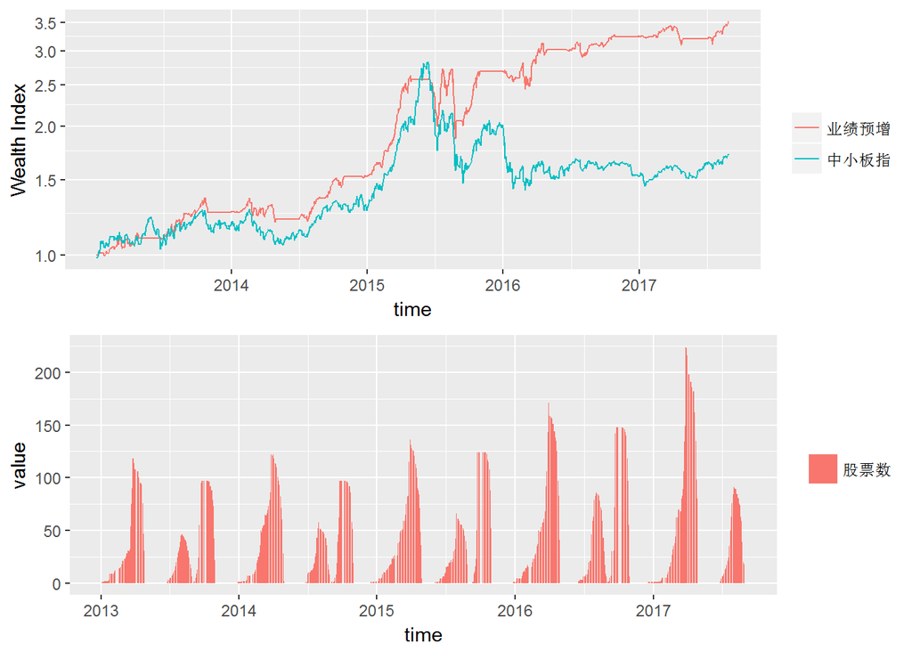

历年收益统计如下表所示。

|  | 业绩预增 | 中小板指 |
| --- | --- | --- |
| 2013-01-04 ~ 2013-12-31 | 26.0% | 17.5% |
| 2014-01-02 ~ 2014-12-31 | 21.4% | 9.7% |
| 2015-01-05 ~ 2015-12-31 | 75.5% | 53.7% |
| 2016-01-04 ~ 2016-12-30 | 21.1% | -22.9% |
| 2017-01-03 ~ 2017-08-30 | 8.1% | 12.9% |
| Cumulative Return | 251.4% | 72.4% |
| Annualized Return | 31.0% | 12.4% |

### (c4)ST摘帽(provided by han.qian)

具体策略可以参见吴先兴的潜伏ST摘帽报告。

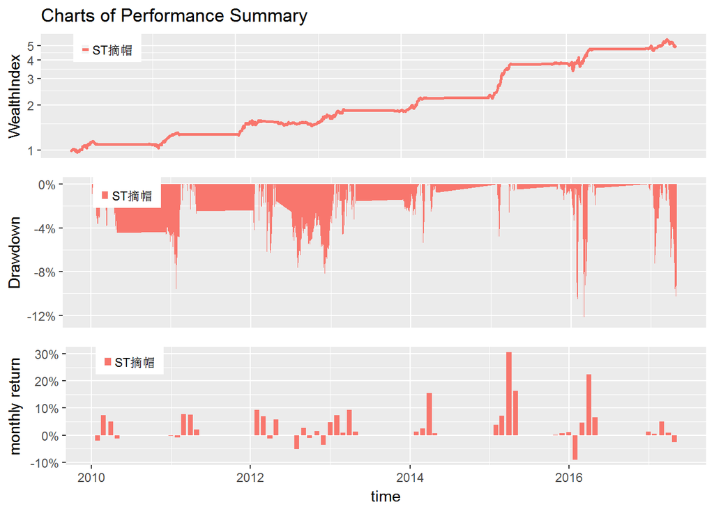

最新持仓如下表所示。

| date | stockID | stockName | wgt |
| --- | --- | --- | --- |
| 2017-04-28 | EQ000505 | 珠江控股 | 0.1 |
| 2017-04-28 | EQ000511 | *ST 烯碳 | 0.1 |
| 2017-04-28 | EQ600339 | 中油工程 | 0.1 |

### (c5)主动量化及指数增强

主动量化基金最近一年和最近一个季度的收益率密度图如下所示。

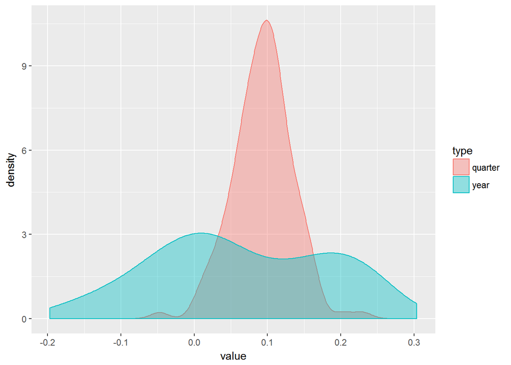

主动量化基金近一年和近一个季度表现最好的20只基金如下表所示。

| 季度排名 | 基金简称 | 成立日 | 总规模 | 季度收益 | 年度排名 | 基金简称 | 成立日 | 总规模 | 年度收益 |
| --- | --- | --- | --- | --- | --- | --- | --- | --- | --- |
| 1 | 九泰久盛量化先锋A | 2015-11-10 | 4.3 | 20.3% | 1 | 景顺长城量化新动力 | 2016-07-13 | 4.0 | 30.4% |
| 2 | 华泰柏瑞量化先行 | 2010-06-22 | 7.8 | 16.9% | 2 | 华泰柏瑞量化优选 | 2014-12-17 | 9.1 | 27.6% |
| 3 | 华泰柏瑞量化智慧 | 2015-06-03 | 5.6 | 16.6% | 3 | 华泰柏瑞量化驱动 | 2015-03-24 | 21.8 | 23.8% |
| 4 | 景顺长城量化精选 | 2015-02-04 | 14.0 | 16.4% | 4 | 华泰柏瑞量化A | 2013-08-02 | 44.3 | 23.4% |
| 5 | 嘉实腾讯自选股大数据 | 2015-12-07 | 5.5 | 16.3% | 5 | 华泰柏瑞量化智慧 | 2015-06-03 | 5.6 | 21.4% |
| 6 | 中融量化智选A | 2017-03-22 | 2.5 | 15.6% | 6 | 华泰柏瑞量化先行 | 2010-06-22 | 7.8 | 20.1% |
| 7 | 华泰柏瑞量化优选 | 2014-12-17 | 9.1 | 15.3% | 7 | 九泰久盛量化先锋A | 2015-11-10 | 4.3 | 18.0% |
| 8 | 华泰柏瑞量化驱动 | 2015-03-24 | 21.8 | 14.2% | 8 | 大成核心双动力 | 2010-06-22 | 1.3 | 11.1% |
| 9 | 永赢量化灵活配置 | 2015-09-01 | 0.7 | 14.2% | 9 | 景顺长城量化精选 | 2015-02-04 | 14.0 | 10.9% |
| 10 | 华泰柏瑞量化A | 2013-08-02 | 44.3 | 14.0% | 10 | 永赢量化灵活配置 | 2015-09-01 | 0.7 | 10.5% |
| 11 | 德邦量化优选A | 2017-03-24 | 0.1 | 13.6% | 11 | 泰达宏利同顺大数据A | 2016-02-23 | 1.8 | 10.3% |
| 12 | 景顺长城量化新动力 | 2016-07-13 | 4.0 | 13.5% | 12 | 工银瑞信量化策略 | 2012-04-26 | 1.7 | 8.6% |
| 13 | 建信多因子量化 | 2016-08-09 | 1.7 | 13.2% | 13 | 泰达宏利量化 | 2016-08-30 | 2.4 | 7.8% |
| 14 | 长信量化多策略A | 2015-07-14 | 3.2 | 12.7% | 14 | 东吴安鑫量化 | 2016-06-03 | 2.4 | 7.3% |
| 15 | 泰达宏利量化 | 2016-08-30 | 2.4 | 12.5% | 15 | 华商大盘量化精选 | 2013-04-09 | 11.6 | 5.6% |
| 16 | 招商量化精选 | 2016-03-15 | 1.7 | 12.4% | 16 | 建信多因子量化 | 2016-08-09 | 1.7 | 4.3% |
| 17 | 泰达宏利同顺大数据A | 2016-02-23 | 1.8 | 12.3% | 17 | 大摩量化配置 | 2012-12-11 | 17.1 | 3.9% |
| 18 | 银华量化智慧动力 | 2016-04-25 | 1.0 | 12.0% | 18 | 泰达宏利改革动力A | 2015-02-13 | 16.6 | 3.9% |
| 19 | 大摩睿成中小盘弹性 | 2017-01-16 | 1.8 | 11.9% | 19 | 嘉实腾讯自选股大数据 | 2015-12-07 | 5.5 | 3.7% |
| 20 | 大成动态量化 | 2016-09-20 | 2.5 | 11.8% | 20 | 民生加银量化中国 | 2016-05-19 | 1.7 | 3.0% |

指数增强基金表现如下所示。

| 基金代码 | 基金简称 | 成立日 | 总规模 | 季度超额收益 | 年度超额收益 |
| --- | --- | --- | --- | --- | --- |
| 590007.OF | 中邮上证380 | 2011-11-22 | 42.1 | -3.8% | -7.7% |
| 110003.OF | 易方达上证50指数A | 2004-03-22 | 96.2 | 0.6% | 2.7% |
| 399001.OF | 中海上证50 | 2010-03-25 | 1.4 | -1.4% | -4.9% |
| 000312.OF | 华安沪深300量化A | 2013-09-27 | 1.7 | 5.8% | 8.0% |
| 110030.OF | 易方达沪深300量化 | 2013-06-07 | 9.2 | 4.2% | 8.4% |
| 003015.OF | 中金沪深300A | 2016-07-22 | 0.1 | 2.3% | -4.6% |
| 100038.OF | 富国沪深300 | 2009-12-16 | 20.9 | 2.2% | 3.1% |
| 000311.OF | 景顺长城沪深300 | 2013-10-29 | 27.0 | 2.0% | 10.8% |
| 000176.OF | 嘉实沪深300增强 | 2014-12-26 | 4.6 | 1.3% | 2.3% |
| 310318.OF | 申万菱信沪深300 | 2013-06-07 | 8.3 | 1.0% | 5.1% |
| 004190.OF | 招商沪深300A | 2017-02-10 | 2.2 | 0.7% |  |
| 003261.OF | 安信沪深300A | 2016-10-12 | 1.5 | 0.5% |  |
| 003876.OF | 华宝兴业沪深300 | 2016-12-09 | 3.5 | -0.2% |  |
| 163407.OF | 兴全沪深300 | 2010-11-02 | 8.9 | -0.5% | 8.3% |
| 200002.OF | 长城久泰沪深300 | 2004-05-21 | 7.8 | -0.9% | 1.7% |
| 001015.OF | 华夏沪深300A | 2015-02-10 | 3.1 | -1.3% | -0.6% |
| 519116.OF | 浦银安盛沪深300 | 2010-12-10 | 1.3 | -1.6% | 3.4% |
| 002310.OF | 创金合信沪深300A | 2015-12-31 | 2.3 | -1.9% | -1.2% |
| 166007.OF | 中欧沪深300A | 2010-06-24 | 0.7 | -2.0% | -2.2% |
| 450008.OF | 国富沪深300 | 2009-09-03 | 2.6 | -5.0% | -4.9% |
| 161825.OF | 银华中证800等权重 | 2013-11-05 | 0.5 | 3.6% | -2.3% |
| 000042.OF | 财通中证100增强A | 2013-03-22 | 0.8 | -0.9% | -6.9% |
| 004194.OF | 招商中证1000A | 2017-03-03 | 1.4 | 2.9% |  |
| 003646.OF | 创金合信中证1000A | 2016-12-22 | 1.9 | 2.6% |  |
| 164508.OF | 国富中证100 | 2015-03-26 | 1.7 | 0.6% | -0.8% |
| 213010.OF | 宝盈中证100 | 2010-02-08 | 1.9 | -0.3% | -0.6% |
| 163808.OF | 中银中证100 | 2009-09-04 | 3.2 | -1.2% | 2.1% |
| 003986.OF | 申万菱信中证500优选 | 2017-01-10 | 3.5 | 10.0% |  |
| 002906.OF | 南方中证500增强A | 2016-11-23 | 1.9 | 2.3% |  |
| 003016.OF | 中金中证500A | 2016-07-22 | 0.1 | 2.1% | 1.9% |
| 161017.OF | 富国中证500 | 2011-10-12 | 9.0 | 1.0% | 6.7% |
| 000478.OF | 建信中证500 | 2014-01-27 | 12.8 | 0.4% | 6.0% |
| 004192.OF | 招商中证500A | 2017-05-17 | NA | -0.3% |  |
| 002311.OF | 创金合信中证500A | 2015-12-31 | 1.7 | -0.9% | 4.9% |
| 002510.OF | 申万菱信中证500 | 2016-04-21 | 2.4 | -4.7% | -4.3% |
| 161507.OF | 银河沪深300成长 | 2013-03-29 | 0.3 | -2.5% | -8.4% |
| 100032.OF | 富国中证红利 | 2008-11-20 | 13.0 | 0.6% | 1.4% |
| 040002.OF | 华安MSCI中国A股 | 2002-11-08 | 25.2 |  |  |
| 161604.OF | 融通深证100AB | 2003-09-30 | 55.9 | -3.8% | -5.2% |
| 410010.OF | 华富中小板 | 2011-12-09 | 0.1 | -4.5% | -8.8% |
| 161613.OF | 融通创业板AB | 2012-04-06 | 5.1 | -3.3% | -3.4% |
| 700002.OF | 平安大华深证300 | 2011-12-20 | 0.6 | -0.4% | 2.1% |
| 233010.OF | 大摩深证300 | 2011-11-15 | 0.5 | -4.5% | -2.0% |
| 161607.OF | 融通巨潮100AB | 2005-05-12 | 8.4 | -0.5% | -4.5% |
| 530018.OF | 建信深证100 | 2012-03-16 | 1.0 | -1.0% | 2.3% |
| 165806.OF | 东吴深证100 | 2012-03-09 | 0.1 | -4.0% | -7.1% |
| 001027.OF | 前海开源中证大农业 | 2015-02-13 | 0.8 | 0.1% | -2.7% |
| 161036.OF | 富国中证娱乐主题 | 2017-03-13 | 1.5 | 2.8% |  |
| 161035.OF | 富国中证医药主题 | 2016-11-11 | 2.3 | 2.5% |  |
| 161037.OF | 富国中证高端制造 | 2017-04-27 | 1.8 | 1.9% |  |
| 180003.OF | 银华道琼斯88精选 | 2004-08-11 | 26.0 |  |  |
| 001397.OF | 建信精工制造 | 2015-08-26 | 2.4 |  |  |

## D、择时

### (d1)等权指数

从历史来看，A股市场存在小盘股效应，市值小的股票长期整体跑赢大市值的股票，美股市场同样存在类似的现象。而目前大部分指数的编制方案都是类似市值加权，为了抛去市值的影响，下面展示几个等权指数，其中中证500等权和沪深300等权是现有的指数，中证全指等权是自己编制的指数。等权指数可以视为一个更好地业绩比较基准。等权指数走势如下图：

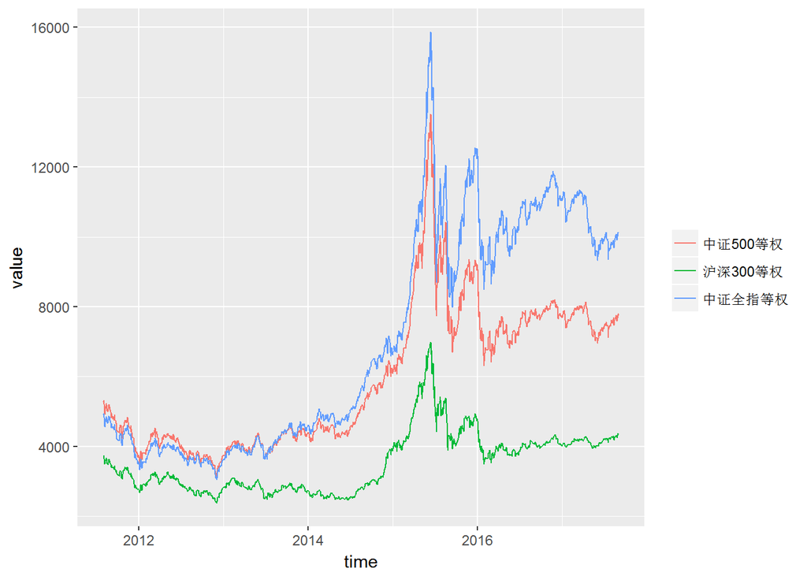

等权指数收益率统计见下表：

|  | 中证500等权 | 沪深300等权 | 中证全指等权 |
| --- | --- | --- | --- |
| 2011-08-02 ~ 2011-12-30 | -29.2% | -25.5% | -27.8% |
| 2012-01-04 ~ 2012-12-31 | -0.0% | 1.5% | 2.2% |
| 2013-01-04 ~ 2013-12-31 | 16.7% | -3.2% | 25.8% |
| 2014-01-02 ~ 2014-12-31 | 40.2% | 43.7% | 46.0% |
| 2015-01-05 ~ 2015-12-31 | 47.6% | 20.1% | 84.4% |
| 2016-01-04 ~ 2016-12-30 | -15.1% | -15.1% | -10.3% |
| 2017-01-03 ~ 2017-08-30 | 1.3% | 8.6% | -8.2% |
| 累计收益率 | 47.1% | 16.6% | 105.8% |
| 年化收益率 | 6.5% | 2.6% | 12.6% |
| 年化波动率 | 28.1% | 25.3% | 28.5% |
| 年化Sharpe值 | 23.3% | 10.1% | 44.2% |
| 最大回撤 | 53.3% | 50.0% | 49.7% |

### (d2)大盘均线强弱指数

大盘均线强弱指数在一定程度上可以视为一个反转指标，当大盘均线得分接近8分时，预示市场接近顶部，当大盘均线得分接近0分时，预示市场接近底部。  
大盘均线强弱指数近一年来走势如下图：

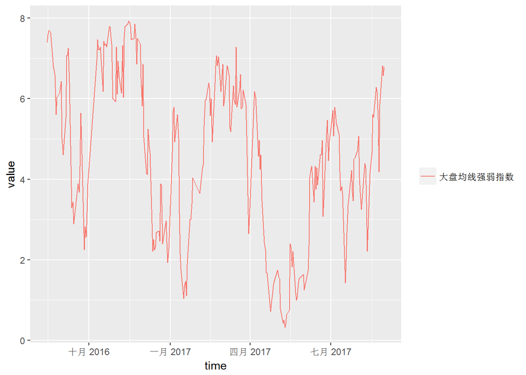

申万一级行业的最新得分见下表：

| 日期 | 指数代码 | 行业 | 最新得分 | 上周得分 |
| --- | --- | --- | --- | --- |
| 2017-08-30 | EI801020 | 采掘 | 8 | 5 |
| 2017-08-30 | EI801030 | 化工 | 8 | 2 |
| 2017-08-30 | EI801040 | 钢铁 | 8 | 5 |
| 2017-08-30 | EI801050 | 有色金属 | 8 | 5 |
| 2017-08-30 | EI801080 | 电子 | 8 | 7 |
| 2017-08-30 | EI801110 | 家用电器 | 8 | 7 |
| 2017-08-30 | EI801120 | 食品饮料 | 8 | 5 |
| 2017-08-30 | EI801170 | 交通运输 | 8 | 5 |
| 2017-08-30 | EI801710 | 建筑材料 | 8 | 5 |
| 2017-08-30 | EI801720 | 建筑装饰 | 8 | 3 |
| 2017-08-30 | EI801780 | 银行 | 8 | 8 |
| 2017-08-30 | EI801790 | 非银金融 | 8 | 8 |
| 2017-08-30 | EI801180 | 房地产 | 7 | 3 |
| 2017-08-30 | EI801750 | 计算机 | 7 | 6 |
| 2017-08-30 | EI801770 | 通信 | 7 | 5 |
| 2017-08-30 | EI801010 | 农林牧渔 | 6 | 6 |
| 2017-08-30 | EI801140 | 轻工制造 | 6 | 0 |
| 2017-08-30 | EI801150 | 医药生物 | 6 | 2 |
| 2017-08-30 | EI801200 | 商业贸易 | 6 | 5 |
| 2017-08-30 | EI801210 | 休闲服务 | 6 | 0 |
| 2017-08-30 | EI801230 | 综合 | 6 | 4 |
| 2017-08-30 | EI801730 | 电气设备 | 6 | 4 |
| 2017-08-30 | EI801760 | 传媒 | 6 | 1 |
| 2017-08-30 | EI801890 | 机械设备 | 6 | 4 |
| 2017-08-30 | EI801130 | 纺织服装 | 5 | 1 |
| 2017-08-30 | EI801160 | 公用事业 | 5 | 5 |
| 2017-08-30 | EI801880 | 汽车 | 5 | 2 |
| 2017-08-30 | EI801740 | 国防军工 | 4 | 4 |

### (d3)LLT及均线择时

LLT本质上是一个改进的单均线择时指标，较原始的均线择时延迟更低。  
择时模型和指数本身的净值走势如下图：

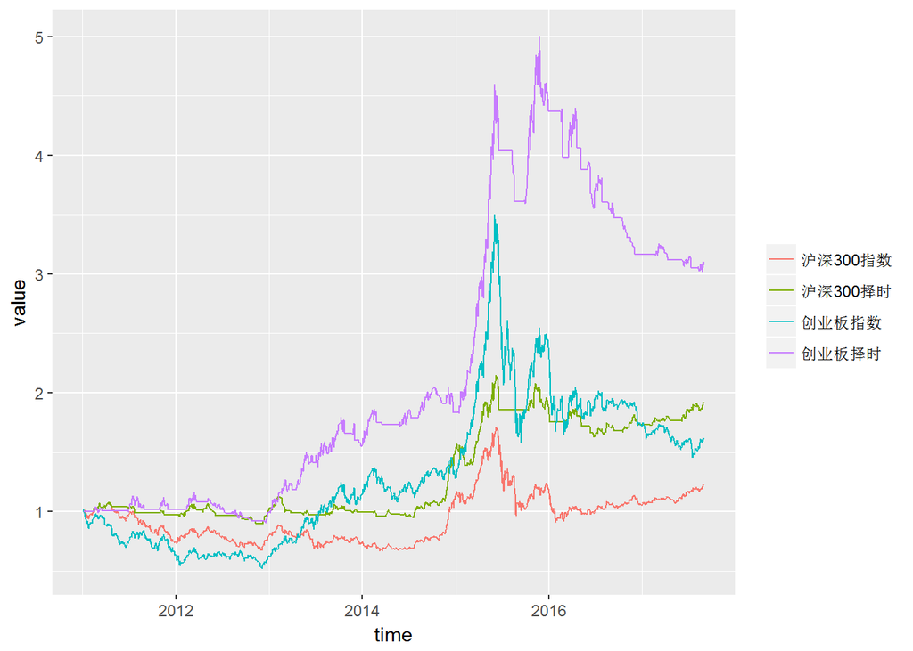

择时模型和指数的收益率统计如下表：

|  | 沪深300指 | 沪深300LLT | 创业板指 | 创业板MA |
| --- | --- | --- | --- | --- |
| 2011-01-04 ~ 2011-12-30 | -25.0% | -2.5% | -35.9% | 1.9% |
| 2012-01-04 ~ 2012-12-31 | 7.6% | 5.4% | -2.1% | -1.7% |
| 2013-01-04 ~ 2013-12-31 | -7.6% | -3.2% | 82.7% | 55.7% |
| 2014-01-02 ~ 2014-12-31 | 51.7% | 52.4% | 12.8% | 17.7% |
| 2015-01-05 ~ 2015-12-31 | 5.6% | 24.3% | 84.4% | 138.1% |
| 2016-01-04 ~ 2016-12-30 | -11.3% | -8.1% | -27.7% | -27.5% |
| 2017-01-03 ~ 2017-08-30 | 15.8% | 10.4% | -6.3% | -2.3% |
| 累计收益率 | 22.6% | 91.5% | 61.6% | 209.4% |
| 年化收益率 | 3.1% | 10.2% | 7.5% | 18.5% |
| 年化波动率 | 23.5% | 15.2% | 32.1% | 21.5% |
| 年化Sharpe值 | 13.2% | 67.6% | 23.3% | 86.0% |
| 最大回撤 | 46.7% | 24.0% | 58.4% | 39.6% |

择时模型最近10个交易日的信号如下表：

| 日期 | 沪深300收盘价 | 沪深300LLT | 沪深300择时信号 | 创业板收盘价 | 创业板MA30 | 创业板择时信号 |
| --- | --- | --- | --- | --- | --- | --- |
| 2017-08-17 | 3721.277 | 3737.791 | hold | 1833.398 | 1743.754 | hold |
| 2017-08-18 | 3724.675 | 3739.906 | hold | 1821.803 | 1743.300 | hold |
| 2017-08-21 | 3740.994 | 3742.508 | hold | 1829.217 | 1744.165 | hold |
| 2017-08-22 | 3752.298 | 3745.829 | hold | 1814.915 | 1745.199 | hold |
| 2017-08-23 | 3756.088 | 3749.428 | hold | 1807.366 | 1745.886 | hold |
| 2017-08-24 | 3734.646 | 3752.226 | hold | 1795.739 | 1746.449 | hold |
| 2017-08-25 | 3795.754 | 3756.126 | hold | 1812.878 | 1748.692 | hold |
| 2017-08-28 | 3842.712 | 3763.298 | hold | 1842.829 | 1754.906 | hold |
| 2017-08-29 | 3834.538 | 3771.329 | hold | 1831.591 | 1760.376 | hold |
| 2017-08-30 | 3834.300 | 3778.641 | hold | 1838.631 | 1765.504 | hold |

### (d4)网格交易

在经历了三轮股灾，A股逐步回归正常，在过去的一段时间呈现一个震荡的格局，如果未来没有增量信息，很可能维持震荡。结合股指期货的贴水，前期研究了一下网格交易。网格交易的结果如下图：

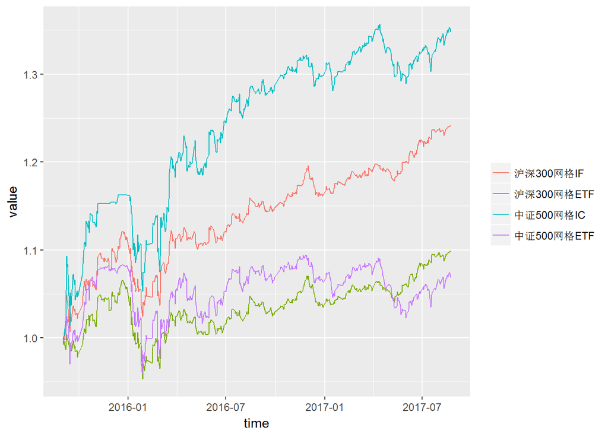

网格交易的收益统计如下表：

|  | 沪深300指数 | 沪深300网格IF | 沪深300网格ETF | 中证500指数 | 中证500网格IC | 中证500网格ETF |
| --- | --- | --- | --- | --- | --- | --- |
| 2015-09-02 ~ 2015-12-31 | 11.0% | 11.1% | 5.6% | 23.5% | 16.2% | 8.1% |
| 2016-01-04 ~ 2016-12-30 | -11.3% | 4.7% | -1.8% | -17.8% | 11.8% | -1.6% |
| 2017-01-03 ~ 2017-08-23 | 13.5% | 6.8% | 6.0% | 0.9% | 3.7% | 0.4% |
| 累计收益率 | 11.7% | 24.2% | 9.9% | 2.5% | 34.7% | 6.8% |
| 年化收益率 | 5.8% | 11.6% | 4.9% | 1.2% | 16.3% | 3.4% |
| 年化波动率 | 20.1% | 8.3% | 8.2% | 27.3% | 12.4% | 10.7% |
| 年化Sharpe值 | 28.7% | 138.5% | 59.7% | 4.6% | 131.3% | 31.7% |
| 最大回撤 | 26.4% | 8.6% | 10.5% | 33.5% | 9.4% | 11.4% |

## E、选股

### (e1)大小市值100

作为多因子选股的第一部分，有必要从市值因子说起。 下面利用总市值因子，在中证全指的成分股内，选出市值最大和最小的100只股票，这里剔除了ST、新上市、停牌和涨停的股票，等权配置，每月换仓一次，交易成本千分之三。观察历年来大、小市值组净值表现如下图。

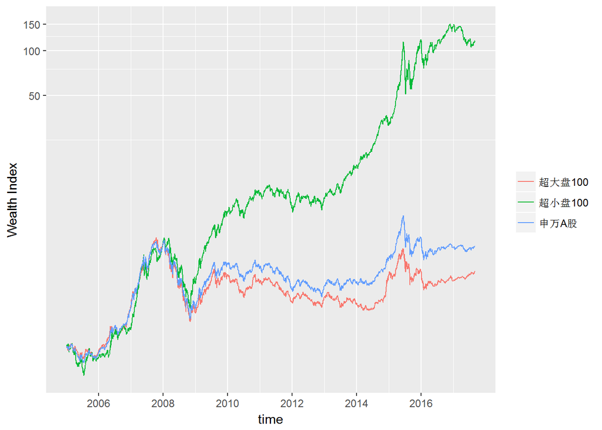

大小市值100的收益统计如下表：

|  | 超大盘100 | 超小盘100 | 申万A股 |
| --- | --- | --- | --- |
| 2005-01-05 ~ 2005-12-30 | -8.0% | -15.5% | -10.1% |
| 2006-01-04 ~ 2006-12-29 | 104.5% | 56.5% | 103.9% |
| 2007-01-04 ~ 2007-12-28 | 163.5% | 270.9% | 167.2% |
| 2008-01-02 ~ 2008-12-31 | -65.6% | -45.1% | -62.8% |
| 2009-01-05 ~ 2009-12-31 | 82.8% | 206.5% | 105.6% |
| 2010-01-04 ~ 2010-12-31 | -9.9% | 32.0% | -6.8% |
| 2011-01-04 ~ 2011-12-30 | -27.2% | -19.5% | -28.6% |
| 2012-01-04 ~ 2012-12-31 | 7.7% | 15.8% | 4.9% |
| 2013-01-04 ~ 2013-12-31 | -9.2% | 65.4% | 6.3% |
| 2014-01-02 ~ 2014-12-31 | 55.5% | 89.8% | 44.9% |
| 2015-01-05 ~ 2015-12-31 | 4.5% | 266.7% | 35.3% |
| 2016-01-04 ~ 2016-12-30 | -13.5% | 24.7% | -13.6% |
| 2017-01-03 ~ 2017-08-30 | 16.3% | -19.9% | 3.3% |
| 累计收益率 | 227.0% | 11580.9% | 386.1% |
| 年化收益率 | 9.8% | 45.6% | 13.3% |
| 年化波动率 | 28.7% | 35.5% | 28.3% |
| 年化Sharpe值 | 34.1% | 128.6% | 47.0% |
| 最大回撤 | 72.9% | 66.4% | 70.5% |

### (e2)银行股轮动

银行股轮动是参考集思录的热门贴银行股评级而来的，数据的提取和参数的设置和原贴有一定的差别，所以轮动的效果也会不太一样，不过回测的效果还不错，从现在开始跟踪。2013年以来银行股轮动的结果如下图：

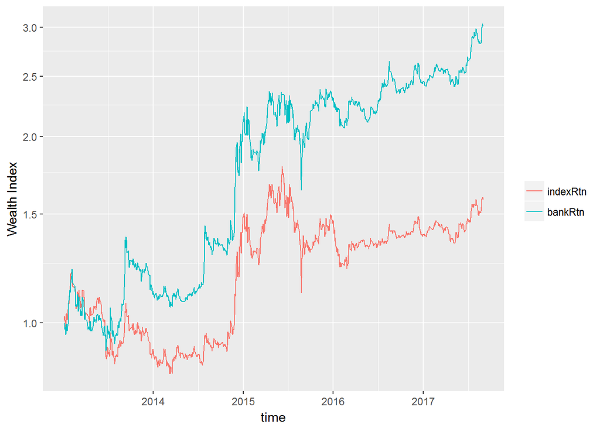

银行股轮动的收益统计如下表：

|  | 申万银行 | 银行股轮动 |
| --- | --- | --- |
| 2013-01-04 ~ 2013-12-31 | -9.2% | 12.5% |
| 2014-01-02 ~ 2014-12-31 | 63.2% | 87.6% |
| 2015-01-05 ~ 2015-12-31 | -1.4% | 9.4% |
| 2016-01-04 ~ 2016-12-30 | -4.9% | 6.2% |
| 2017-01-04 ~ 2017-08-30 | 13.9% | 23.0% |
| 累计收益率 | 58.2% | 201.7% |
| 年化收益率 | 10.3% | 26.8% |
| 年化波动率 | 27.3% | 29.2% |
| 年化Sharpe值 | 37.9% | 91.5% |
| 最大回撤 | 37.4% | 30.8% |

银行股轮动的最新得分如下表：

| 日期 | 代码 | 简称 | PB | ROE | 翻倍期 | 持仓 |
| --- | --- | --- | --- | --- | --- | --- |
| 2017-08-30 | EQ600015 | 华夏银行 | 0.81 | 0.12 | 4.1 |  |
| 2017-08-30 | EQ601818 | 光大银行 | 0.79 | 0.12 | 4.2 |  |
| 2017-08-30 | EQ601328 | 交通银行 | 0.78 | 0.11 | 4.5 | hold |
| 2017-08-30 | EQ600016 | 民生银行 | 0.90 | 0.14 | 4.6 |  |
| 2017-08-30 | EQ601288 | 农业银行 | 0.95 | 0.14 | 5.0 |  |
| 2017-08-30 | EQ601998 | 中信银行 | 0.84 | 0.11 | 5.1 |  |
| 2017-08-30 | EQ600000 | 浦发银行 | 0.98 | 0.14 | 5.1 |  |
| 2017-08-30 | EQ601988 | 中国银行 | 0.89 | 0.11 | 5.4 |  |
| 2017-08-30 | EQ601166 | 兴业银行 | 1.06 | 0.14 | 5.7 |  |
| 2017-08-30 | EQ601169 | 北京银行 | 0.99 | 0.12 | 5.9 |  |
| 2017-08-30 | EQ601398 | 工商银行 | 1.08 | 0.14 | 6.0 |  |
| 2017-08-30 | EQ601939 | 建设银行 | 1.11 | 0.14 | 6.0 |  |
| 2017-08-30 | EQ601009 | 南京银行 | 1.12 | 0.14 | 6.1 |  |
| 2017-08-30 | EQ000001 | 平安银行 | 0.97 | 0.11 | 6.5 |  |
| 2017-08-30 | EQ600919 | 江苏银行 | 1.23 | 0.13 | 7.4 |  |
| 2017-08-30 | EQ601997 | 贵阳银行 | 1.71 | 0.17 | 7.7 |  |
| 2017-08-30 | EQ002142 | 宁波银行 | 1.61 | 0.16 | 7.9 |  |
| 2017-08-30 | EQ601229 | 上海银行 | 1.28 | 0.12 | 8.2 |  |
| 2017-08-30 | EQ600036 | 招商银行 | 1.70 | 0.16 | 8.4 |  |
| 2017-08-30 | EQ600926 | 杭州银行 | 1.41 | 0.10 | 10.5 |  |
| 2017-08-30 | EQ601128 | 常熟银行 | 2.49 | 0.11 | 15.4 |  |
| 2017-08-30 | EQ600908 | 无锡银行 | 2.46 | 0.11 | 15.8 |  |
| 2017-08-30 | EQ603323 | 吴江银行 | 2.18 | 0.09 | 17.9 |  |
| 2017-08-30 | EQ002807 | 江阴银行 | 2.45 | 0.09 | 18.9 |  |
| 2017-08-30 | EQ002839 | 张家港行 | 3.60 | 0.09 | 23.2 |  |